# Código para estimar la densidad de Xt

Gerardo Martínez

13 de noviembre de 2018

El siguiente código mostrará cómo obtener estimaciones de la densidad de $X_t$ para un tiempo $T$ fijo y siendo $X = \{X_t\}_{t \geq 0}$ la difusión límite del modelo de Wright-Fisher con selección y mutación.

Recordemos que el proceso de difusión límite es solución de la ecuación diferencial estocástica

$$\begin{equation*}
\left\{
\begin{array}{rcl}
dX_t & = & (-u_1X_t + u_2 (1-X_t) + \\
& & X_t^2 (1-X_t) \sigma_{11} + X_t (1-X_t)(1-2X_t) \sigma_{12} - X_t(1-X_t)^2 \sigma_{22}) dt \\
& & + \sqrt{X_t(1-X_t)} \, dW_t \\
X_0 & = & p_0 \in (0,1)
\end{array}
\right.
\end{equation*}$$
donde
$$\begin{equation}
\omega_{ij} = 1 + \frac{\sigma_{ij}}{2N}, \qquad \mu_i = \frac{u_i}{2N}
\end{equation}$$

Para obtener una estimación de la densidad de $X_t$ para un tiempo $t$ fijo, la idea será obtener muchas trayectorias de $X = \{X_t\}_{t \geq 0}$ en $[0,T]$ según el esquema de Milstein y quedarnos con el valor de $X_T$.

La función $\texttt{simulacionXt()}$ es una modificación de la función $\texttt{trayectoriasWFMS()}$ que, en vez de devolver una matriz con los valores de las trayectorias simuladas entre $[0,T]$, devuelve un vector de tamaño $k$ con los valores simulados de $X_t$. Al igual que $\texttt{trayectoriasWFMS()}$, esta función toma como parámetros el número el número de trayectorias $k$, la precisión del esquema de Milstein $n$ y los parámetros del modelo $p_0$, $N$, $\mu_1$, $\mu_2$, $\sigma_{11}$, $\sigma_{12}$ y $\sigma_{22}$.

```r
simulacionXt <- function(k, n, T, p0, N, u1, u2, s11, s12, s22) {

  densidadt <- densidadt <- rep(0, times = k)

    if (u1 == 0) {
        if (u2 == 0) {
            for (j in 1:k) {
                # Inicialización
                tr <- rep(0, times = n + 1)
                tr[1] <- p0

                # Bucle
                for (i in 1:n) {
                    if (tr[i] != 0) {
                        if (tr[i] != 1) {

                            # si la frecuencia del alelo
                            # es distinta de 0 o 1,
                            # utilizo el proceso de difusión

                            W <- sqrt(T / n) * rnorm(1)
                            tr[i + 1] <- tr[i] +
                            (tr[i]) ^ 2 * (1 - tr[i]) * 2 * N *s11 * T / n +
                            (tr[i]) * (1 - tr[i]) * (1 - 2 * tr[i]) * 2 * N * s12 * T / n -
                            (tr[i]) * (1 - tr[i]) ^ 2 * 2 * N * s22 * T / n +
                            sqrt(tr[i] * (1 - tr[i])) * W +
                            (((-2 * tr[i] + 1) / (4)) * (W ^ 2 - T / n))

                            # en caso de que por error de siulación
                            # se obtenga un valor menor que 0
                            if (tr[i + 1] <= 0) {
                            tr[i + 1] <- 0
                            }

                            # en caso de que por error de siulación
                            # se obtenga un valor mayor que 1
                            if (tr[i + 1] >= 1) {
                            tr[i + 1] <- 1
                            }

                        } else {
                            tr[i + 1] <- 1
                        }
                    } else {
                        tr[i + 1] <- 0
                    }
                }

                densidadt[j] <- tr[n+1]
            }
        }   else{
            for (j in 1:k){
                # Inicialización
                tr <- rep(0, times = n+1)
                tr[1] <- p0

                # Bucle
                for (i in 1:n){
                    if (tr[i] != 1){
                        W <- sqrt(T/n)*rnorm(1)

                        tr[i+1] <- tr[i] +
                            u2*(1 - tr[i])*2*N*T/n +
                            (tr[i])*(1-tr[i])*s11*2*N*T/n +
                            (tr[i])*(1-tr[i])*(1-2*tr[i])*s12*2*N*T/n -
                            (tr[i])*(1-tr[i])^2*s22*2*N*T/n +
                            sqrt(tr[i]*(1-tr[i]))*W +
                            (((-2 * tr[i] +1)/(4)) * (W^2 - T/n))

                        # en caso de que por error de siulación
                        # se obtenga un valor menor que 0
                        if (tr[i+1]<=0){
                            tr[i+1] <- 0
                        }

                        # en caso de que por error de siulación
                        # se obtenga un valor mayor que 1
                        if (tr[i+1]>=1){
                            tr[i+1] <- 1
                        }
                    } else {
                        tr[i+1] <- 1
                    }
                }
            densidadt[j] <- tr[n+1]
            }
        }
    }   else{
            if(u2 == 0){
                for (j in 1:k){
                    # Inicialización
                    tr <- rep(0, times = n+1)
                    tr[1] <- p0

                    # Bucle
                    for (i in 1:n){
                        if (tr[i] != 0){
                            W <- sqrt(T/n)*rnorm(1)

                            tr[i+1] <- tr[i] +
                                -u1*tr[i]*2*N*T/n +
                                (tr[i])*(1-tr[i])*s11*2*N*T/n +
                                (tr[i])*(1-tr[i])*(1-2*tr[i])*s12*2*N*T/n -
                                (tr[i])*(1-tr[i])^2*s22*2*N*T/n +
                                sqrt(tr[i]*(1-tr[i]))*W +
                                (((-2 * tr[i] +1)/(4)) * (W^2 - T/n))

                            # en caso de que por error de siulación
                            # se obtenga un valor menor que 0
                            if (tr[i+1]<=0){
                                tr[i+1] <- 0
                            }

                            # en caso de que por error de siulación
                            # se obtenga un valor mayor que 1
                            if (tr[i+1]>=1){
                                tr[i+1] <- 1
                            }
                        } else {
                            tr[i+1] <- 0
                        }
                    }
                    densidadt[j] <- tr[n+1]
                }
            }   else{
                    for (j in 1:k){
                        # Inicialización
                        tr <- rep(0, times = n+1)
                        tr[1] <- p0

                        # Bucle
                        for (i in 1:n){
                            W <- sqrt(T/n)*rnorm(1)

                            tr[i+1] <- tr[i] +
                                -u1*tr[i]*2*N*T/n +
                                u2*(1 - tr[i])*2*N*T/n +
                                (tr[i])*(1-tr[i])*s11*2*N*T/n +
                                (tr[i])*(1-tr[i])*(1-2*tr[i])*s12*2*N*T/n -
                                (tr[i])*(1-tr[i])^2*s22*2*N*T/n +
                                sqrt(tr[i]*(1-tr[i]))*W +
                                (((-2 * tr[i] +1)/(4)) * (W^2 - T/n))

                            # en caso de que por error de siulación
                            # se obtenga un valor menor que 0
                            if (tr[i+1]<=0){
                                tr[i+1] <- 0
                            }

                            # en caso de que por error de siulación
                            # se obtenga un valor mayor que 1
                            if (tr[i+1]>=1){
                                tr[i+1] <- 1
                            }
                        }
                    densidadt[j] <- tr[n+1]
                    }
                }
    }
    return(densidadt)
}
```

Crearemos un vector *densidadt* que tendrá los resultados de $X_T$ con $T = 100$ para una difusión de parámetros $p_0 = 0.5, \sigma_{11} = \sigma_{12} = \sigma_{22} = 0$ y $u_1 = u_2 = 2N 0.1$ con $N = 100$.

```r
densidadt <- simulacionXt(k = 1e3,
                          n = 1e5,
                          T = 100,
                          N = 100,
                          u1 = 0.1,
                          u2 = 0.1,
                          s11 = 0,
                          s12 = 0,
                          s22 = 0,
                          p0 = 0.5)
```

De forma opcional, se pueden guardar los resultados del vector *densidadt* en un archivo utilizando la función $\texttt{cat()}$. Esta función tiene un parámetro obligatorio $\texttt{file = }$ que toma como valor el nombre que se le quiere asignar al archivo. Adicionalmente, si queremos guardar el vector como una tira de valores sin saltos de línea, tenemos que fijar el parámetro $\texttt{fill = F}$. Se puede también fijar el separador de los valores con el parámetro $\texttt{sep = }$. A modo de ejemplo:

```r
cat(densidadt,
    file = "densidad.txt",
    fill = F,
    sep = ",")
```

Para graficar un histograma de $X_t$ utilizaremos los paquetes $\texttt{ggplot2}$ y $\texttt{latex2exp}$.

```r
library(ggplot2)
library(latex2exp)
```

Construiremos un *dataframe* auxiliar, necesario para graficar utilizando $\texttt{ggplot2}$.

```r
densidad <- data.frame(densidadt)
```

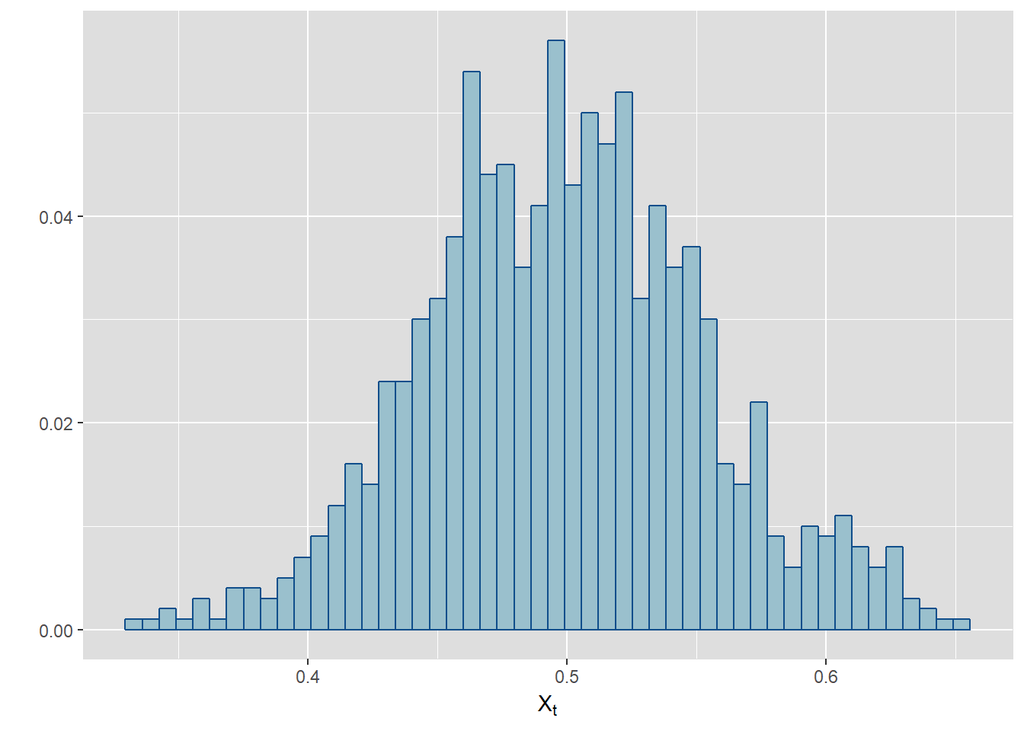

```r
ggplot(densidad, aes(x=densidadt))+
  geom_histogram(bins = 50, color="dodgerblue4", fill = "lightblue3", aes(y=..count../sum(..count..))) +   theme(panel.background = element_rect(fill = "gray87",
                                  colour = "gray87",
                                  size = 0.5, linetype = "solid"),
    panel.grid.major = element_line(size = 0.5, linetype = 'solid',
                                  colour = "white"),
    panel.grid.minor = element_line(size = 0.25, linetype = 'solid',
                                  colour = "white")
    ) +
  xlab(TeX("X_t")) +
  ylab("")
```